# Stamps Report

Alberto Castillo

5/31/2018

## Show total amount of purchases in each month by each company

Here we create a stacked bar graph to visualize how many purchases occured by every month for each company. We can clearly the the numbers in white for each customer. The stacked bar graph is in order exactly like the legend so as you move down each square you would follow along with the legend.

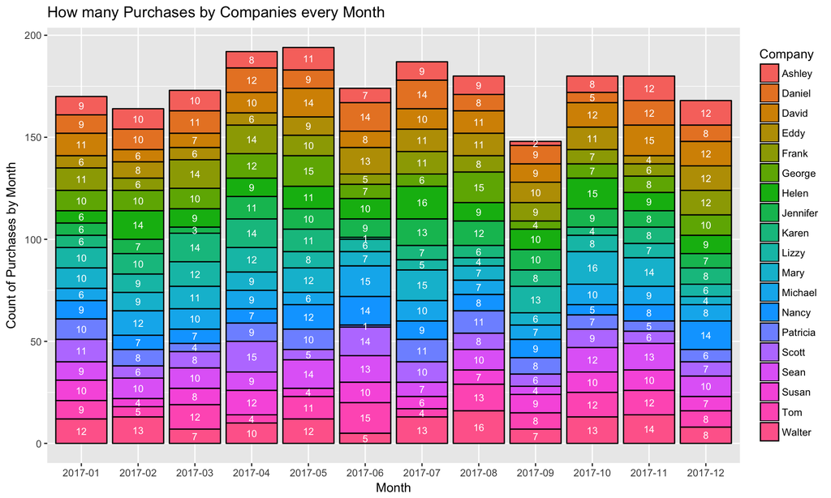

```r
Purchase_Data %>%
  ggplot(aes(x = format(Date, "%Y-%m"), fill = Company))+
  geom_bar(color = 'Black') +
  labs(x = 'Month', y = "Count of Purchases by Month", title = "How many Purchases by Companies every Month")+
  geom_text(stat = 'count', aes(label=..count..), size = 3, position = position_stack(vjust = 0.5), color="white")
```

## Billing for each Company at the end of the month. This is the largest bill that Stamps will collect in the entire year

We want find the value of our bills we need to charge at the end of each month. The bill is calculated at the sum of the purchases a company creates minus the value of the payment they made in the same period. In our data payments are denoted as (-) so in our data we do an addition. Finally we want to see what the maximum amout of money we will collect in this year will be.

```r
Bill_Data <- Purchase_Data %>%
  group_by(month, Company) %>%
  summarise(sum_spend = sum(Spend, na.rm = TRUE), sum_payment = sum(Payment, na.rm = TRUE), Bill = sum_spend + sum_payment)
max(Bill_Data$Bill)
```

```
## [1] 9059216
```

## What is the dollar amount of each customers highest bill

Now we want to see what is the dollar amount of the higest bill for each customer. This is the amount of money that each company owes.

```r
Bill_Data %>%
  group_by(Company) %>%
  summarise(max_bill = max(Bill))
```

```
## # A tibble: 19 x 2
##    Company  max_bill
##    <chr>       <dbl>
##  1 Ashley    3797052
##  2 Daniel    5552764
##  3 David     3175100
##  4 Eddy      6547000
##  5 Frank     7165700
##  6 George    4702180
##  7 Helen     5999811
##  8 Jennifer  5535789
##  9 Karen     8128001
## 10 Lizzy      609204
## 11 Mary      7590764
## 12 Michael   4443700
## 13 Nancy     2562226
## 14 Patricia   700211
## 15 Scott     9059216
## 16 Sean      5700200
## 17 Susan     4427353
## 18 Tom       5870400
## 19 Walter    4119100
```

## Profit margins is a flat percentage. 1st, 4th, 6th profitable person

Now we want to see which companies are the most profitable for us. So we look at the total amount of purchases that is made by each specific company. Then we order them from the largest total purchase to the smallest and return the values we are looking for: The most profitable companies.

```r
Profitable_margin_customers <- Purchase_Data %>%
  group_by(Company) %>%
  summarise(total_purchase = sum(Spend, na.rm = TRUE)) %>%
  arrange(desc(total_purchase))
Profitable_margin_customers[1,]
```

```
## # A tibble: 1 x 2
##   Company total_purchase
##   <chr>            <dbl>
## 1 Scott         68201664
```

```r
Profitable_margin_customers[4,]
```

```
## # A tibble: 1 x 2
##   Company total_purchase
##   <chr>            <dbl>
## 1 David         58145300
```

```r
Profitable_margin_customers[6,]
```

```
## # A tibble: 1 x 2
##   Company total_purchase
##   <chr>            <dbl>
## 1 Mary          52393670
```

## Credit Exposure

Since most companies are not paying their entire orders in one payment, but have spread them out over an amount of time. We need to determine what our exposure is, that is, how much would we be in debt if our customers suddenly went bankrupt. We can see that some months we are (-) which means that these months companies made enough payments to push us into cash flow positive territory.

```r
Bill_Data %>%
  group_by(month) %>%
  summarise(credit_exposure = sum(Bill))
```

```
## # A tibble: 12 x 2
##    month credit_exposure
##    <chr>           <dbl>
##  1 01           53271317
##  2 02           32906230
##  3 03           24391771
##  4 04           20712338
##  5 05           23166734
##  6 06            3896696
##  7 07          - 3090934
##  8 08          -22527905
##  9 09            5832091
## 10 10           42366148
## 11 11          -47902177
## 12 12          - 3728272
```

## Most Valueable Customer YTD. If we go off the same as in question 4 and choose 1, 4, 6

We have looked at the most valueable customer when it comes to the total amount of purchases made, but now we are looking for the most valueable customers that are making the most payments on their purchases.

```r
Customer_Payments <- Purchase_Data %>%
  group_by(Company) %>%
  summarise(total_payments = sum(Payment, na.rm = TRUE)) %>%
  arrange(total_payments)
Customer_Payments[1,]
```

```
## # A tibble: 1 x 2
##   Company total_payments
##   <chr>            <dbl>
## 1 Scott        -63209095
```

```r
Customer_Payments[4,]
```

```
## # A tibble: 1 x 2
##   Company total_payments
##   <chr>            <dbl>
## 1 Mary         -51800000
```

```r
Customer_Payments[6,]
```

```
## # A tibble: 1 x 2
##   Company total_payments
##   <chr>            <dbl>
## 1 Sean         -49523100
```

## The Highest Payments Per Month by each Company

We can break down our information of payments to look at who is making the highest payment by month.

```r
Customer_Payments_month1 <- Purchase_Data %>%
  group_by(Company, month) %>%
  summarise(total_payments = sum(Payment, na.rm = TRUE)) %>%
  group_by(month) %>%
  summarise(total_payments = min(total_payments))
Customer_Payments_month2 <- Purchase_Data %>%
  group_by(Company, month) %>%
  summarise(total_payments = sum(Payment, na.rm = TRUE))
Customer_Payments_month <- left_join(Customer_Payments_month1, Customer_Payments_month2, by = c('month', 'total_payments'))

Customer_Payments_month
```

```
## # A tibble: 12 x 3
##    month total_payments Company
##    <chr>          <dbl> <chr>
##  1 01         - 4272000 Lizzy
##  2 02         -10000000 Scott
##  3 03         - 9045600 Frank
##  4 04         - 9000000 Scott
##  5 05         -10000000 Walter
##  6 06         -12169922 Daniel
##  7 07         -13400000 Jennifer
##  8 08         -13068510 George
##  9 09         - 5108500 David
## 10 10         - 6240000 Michael
## 11 11         -45000000 Mary
## 12 12         - 9923400 Eddy
```

## Total Amount of Purchases by each Company for each Billing Cycle

Here we want to see what the total amount of purchases in dollar value is for each company in the billing cycle beginning on the 16th of every month and ending on the 15th.

```r
Billing_Cycle <- left_join(January_Billing_Cycle, February_Billing_Cycle, by='Company') %>%
  left_join(., March_Billing_Cycle, by = "Company") %>%
  left_join(., April_Billing_Cycle, by='Company') %>%
  left_join(., May_Billing_Cycle, by = "Company") %>%
  left_join(., June_Billing_Cycle, by = 'Company') %>%
  left_join(., July_Billing_Cycle, by= 'Company') %>%
  left_join(., August_Billing_Cycle, by = "Company") %>%
  left_join(., September_Billing_Cycle, by = "Company") %>%
  left_join(., October_Billing_Cycle, by = "Company") %>%
  left_join(., November_Billing_Cycle, by = "Company")
Billing_Cycle
```

```
## # A tibble: 19 x 12
##    Company   January February   March   April     May    June    July
##    <chr>       <dbl>    <dbl>   <dbl>   <dbl>   <dbl>   <dbl>   <dbl>
##  1 Ashley    3098183  5745574 3138154 4348063 4111703 2894911 1805020
##  2 Daniel    5456225  4291621 5720926 5752545 6390772 4940389 6886136
##  3 David     2628400  4991700 4945100 5000600 4431500 2214500 5753400
##  4 Eddy      4261600  1369600 5117200 2938300 6096200 6313500 2228200
##  5 Frank     4209800  3626900 9199100 4813100 1254100 2907300 5482600
##  6 George    4755520  1926960 2246930 2627170 5117280 3466190 3450860
##  7 Helen     3568047  5011199 3311189 3927736 3635539 4842149 3960818
##  8 Jennifer  2719514  1572964 2797997 3438740 3562300 4700405 6040675
##  9 Karen     2659484  6536110 6626620 3754103 3879444 1436659 3575490
## 10 Lizzy     5855749  5027807 3960768 1804324 3085114 1635378 1164010
## 11 Mary      3342360  5376971 6827838 4410938 3980587 3242041 4948087
## 12 Michael   2989700  6417600 3788500 2579400 3942500 5546300 3118400
```

[output cut: 28 more lines]

## Visualizing our Data

Here we want to see how the purchases of all the companies look across the entire year of 2017. Plotting each respective company we can go ahead and smooth out the data to see if we can determine any form of trend by each company. This will be a start for our machine learning to come for the forecasting of the year of 2018 by each company.

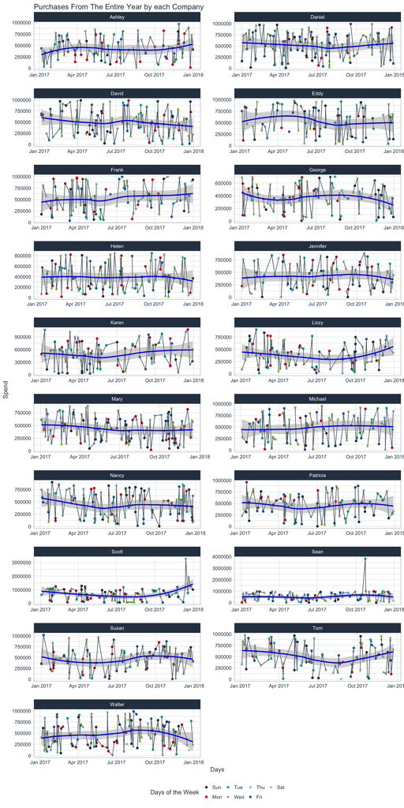

```r
Purchase_Data %>%
  ggplot(aes(x = Date, y = Spend, group = 1))+
  facet_wrap(~ Company, ncol = 2, scales = 'free')+
  geom_point(aes(color = day_of_week), na.rm = TRUE)+
  geom_line(na.rm = TRUE, show.legend = FALSE, color = palette_light()[[1]], alpha = 0.8)+
  geom_smooth(na.rm = TRUE, color = 'blue')+
  scale_color_manual(values = palette_light())+
  theme_tq()+
  labs(color = "Days of the Week", title = "Purchases From The Entire Year by each Company", x = 'Days')
```